# Creating a summarized Experiment

Marc A.T. Teunis

2019-05-15

# Contents

**## Check out new package `biomartr` with organism centric queries… compare to old way with `biomaRt`**

# 1 Packages

## 1.1 Reading data

Data was obtained from Dr. Jean Paul Ten Klooster (date: 06-02-2017) This file contains the sample information (columns or also called colData), the featureData (or `gene_id` names -> `ensembl_id`)

The files that belong to this dataset are called: “./data/jp_counts.txt” (the count data) “./data/jp_coldata.txt (the sample information)”./data/jp_features.txt (gene_ensembl ids and corresponding gene names (symbol)) “./data/jp_miame.txt” (additional info - experimentData)

In this exercise you will learn how to construct a summarized experiment and from individual datafiles, and from there a DESeq2 expression set.

# 2 Prequisites:

- Go over the vignette for the package `{SummarizedExperiment}`.

To recap:

# 3 SummarizedExperiment

*SummarizedExperiment* diagram of the three component pieces:

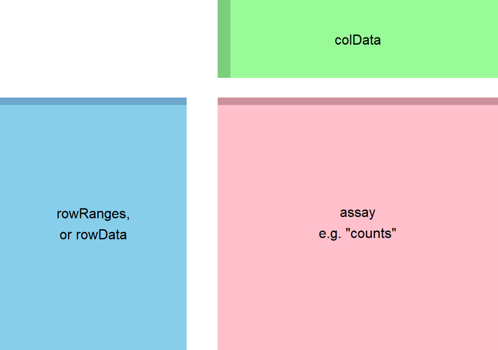

Figure 1: The component parts of a *SummarizedExperiment* object  
The ‘assay’ (pink block) contains the matrix of counts, the ‘rowRanges’ or ‘rowData’ (blue block) contains information about the genomic ranges and the ‘colData’ (green block) contains information about the samples. The highlighted line in each block represents the first row (note that the first row of ‘colData’ lines up with the first column of the ‘assay’).

The *SummarizedExperiment* container is diagrammed in the Figure above and discussed in the latest Bioconductor paper [@Huber2015Orchestrating]. In our case we have created a single matrix named `"counts"` that contains the estimated counts for each gene and sample, which is stored in `assay`. It is also possible to store multiple matrices, accessed with `assays`. The `rowData` for our object will keep track of the intermediate calculations for each gene: e.g. the mean of normalized counts, the dispersion estimates, the estimated coefficients and their standard error, etc. We can also include information about the location of each gene, in which case, we would use `rowRanges` to access the *GenomicRanges* or *GenomicRangesList* associated with each gene.The component parts of the *SummarizedExperiment* are accessed with an R function of the same name: `assay` (or `assays`), `rowRanges`/`rowData` and `colData`.

## 3.1 DESeq2 and edgeR

For running *DESeq2* or *edgeR* models, you can use R’s formula notation to express any fixed-effects experimental design. Note that *DESeq2* and *edgeR* use the same formula notation as, for instance, the *lm* function of base R. If the research aim is to determine for which genes the effect of treatment is different across groups, then interaction terms can be included and tested using a design such as `~ group + treatment + group:treatment`. See the manual page for `?results` for more examples.

# 4 Question 1

1. Load these 4 data files (see below jp_…..txt) into R. Be sure to read the data with the appropriate function.
2. Inspect each file when read into R (with a code chunk below). What can you tell about the underlying relationship between these 4 files

```
## [[1]]
## # A tibble: 2 x 9
##   gene_id `HU_1-NS-012-05~ `HU_1-NS-012-05~ `HU_2-NS-012-05~ `HU_2-NS-012-05~
##   <chr>              <dbl>            <dbl>            <dbl>            <dbl>
## 1 ENSMUS~              489              532              535              465
## 2 ENSMUS~                0                0                0                0
## # ... with 4 more variables:
## #   `HU_3-NS-012-055_S55_L001_R1_001.fastq.count` <dbl>,
## #   `HU_3-NS-012-055_S55_L001_R2_001.fastq.count` <dbl>,
## #   `HU_4-NS-012-056_S56_L001_R1_001.fastq.count` <dbl>,
## #   `HU_4-NS-012-056_S56_L001_R2_001.fastq.count` <dbl>
##
## [[2]]
## # A tibble: 2 x 6
##   treatment   sample_name         cell_type exposure read_direction condition
##   <chr>       <chr>               <chr>     <chr>    <chr>          <chr>
## 1 JAWSIIuntr~ HU_1-NS-012-053_S5~ JAWSII    untreat~ forward        A
## 2 JAWSIIuntr~ HU_1-NS-012-053_S5~ JAWSII    untreat~ reverse        A
##
## [[3]]
## # A tibble: 2 x 2
##   ensembl_id         gene_name
##   <chr>              <chr>
## 1 ENSMUSG00000000001 Gnai3
## 2 ENSMUSG00000000003 Pbsn
```

```
## # A tibble: 8 x 1
##   X1
##   <chr>
## 1 Jean Paul Ten-Klooster
## 2 Marc Teunis
## 3 Innovative Testing Lab
## 4 int@fnt@hu.nl
## 5 T-cell - Dendritic cells interactions
## 6 RNAseq
## 7 www.innovativetesting.nl
## 8 Created from MS Excel file recieved on 6 feb. 2017
```

# 5 Question 2 ExpressionSet

In this question you will need to create a SummarizedExperiment from the four individual data objects loaded above.

1. Create a summarized experiment formal class object

**TIPS**

- See the Vignette for the package `{SummarizedExperiment}`
- We are `contructing` a new object here…
- make sure that the colnames of the counts DataFrame are equal to the rownames of the colData, correct if neccessary
- Look at the help for `SummarizedExperiment()` to get more details on the constructor

The code for the answer to question 2A below should contain the following steps:

1. `Set rownames of pheno_data and convert to class AnnotatedDataFrame(). Convert all factor variables to factors.`
2. `Set rownames of feature_data and convert to AnnotatedDataFrame()`
3. `Remove first column of counts, leave only count data`
4. `Check if rownames(pheno_data) is equal to colnames(counts)`
5. `Fix rownames and if neccessary`
6. `create metadata (need to be a list)`
7. `Create an ExpressionSet from the counts and the colData. Create a matrix with ensembl ids as rownames. The colData needs to be of class AnnotatedDataFrame.`
8. `From the ExpressionSet create a SummarizedExperiment. Add the metadata and the feature data. You can create the SummarizedExperiment from the ExpressionSet with the function:`makeSummarizedExperimentFromExpressionSet()``

```
##                                                    treatment
## HU_1-NS-012-053_S53_L001_R1_001.fastq.count JAWSIIuntreatedF
## HU_1-NS-012-053_S53_L001_R2_001.fastq.count JAWSIIuntreatedR
## HU_2-NS-012-054_S54_L001_R1_001.fastq.count       JAWSIILPSF
## HU_2-NS-012-054_S54_L001_R2_001.fastq.count       JAWSIILPSR
## HU_3-NS-012-055_S55_L001_R1_001.fastq.count    EL4untreatedF
## HU_3-NS-012-055_S55_L001_R2_001.fastq.count    EL4untreatedR
## HU_4-NS-012-056_S56_L001_R1_001.fastq.count EL4JAWSIILPSSUPF
## HU_4-NS-012-056_S56_L001_R2_001.fastq.count EL4JAWSIILPSSUPR
##                                                                             sample_name
## HU_1-NS-012-053_S53_L001_R1_001.fastq.count HU_1-NS-012-053_S53_L001_R1_001.fastq.count
## HU_1-NS-012-053_S53_L001_R2_001.fastq.count HU_1-NS-012-053_S53_L001_R2_001.fastq.count
## HU_2-NS-012-054_S54_L001_R1_001.fastq.count HU_2-NS-012-054_S54_L001_R1_001.fastq.count
## HU_2-NS-012-054_S54_L001_R2_001.fastq.count HU_2-NS-012-054_S54_L001_R2_001.fastq.count
## HU_3-NS-012-055_S55_L001_R1_001.fastq.count HU_3-NS-012-055_S55_L001_R1_001.fastq.count
## HU_3-NS-012-055_S55_L001_R2_001.fastq.count HU_3-NS-012-055_S55_L001_R2_001.fastq.count
## HU_4-NS-012-056_S56_L001_R1_001.fastq.count HU_4-NS-012-056_S56_L001_R1_001.fastq.count
## HU_4-NS-012-056_S56_L001_R2_001.fastq.count HU_4-NS-012-056_S56_L001_R2_001.fastq.count
##                                              cell_type  exposure
## HU_1-NS-012-053_S53_L001_R1_001.fastq.count     JAWSII untreated
## HU_1-NS-012-053_S53_L001_R2_001.fastq.count     JAWSII untreated
## HU_2-NS-012-054_S54_L001_R1_001.fastq.count     JAWSII       LPS
## HU_2-NS-012-054_S54_L001_R2_001.fastq.count     JAWSII       LPS
## HU_3-NS-012-055_S55_L001_R1_001.fastq.count        EL4 untreated
## HU_3-NS-012-055_S55_L001_R2_001.fastq.count        EL4 untreated
## HU_4-NS-012-056_S56_L001_R1_001.fastq.count EL4-JAWSII       SUP
## HU_4-NS-012-056_S56_L001_R2_001.fastq.count EL4-JAWSII       SUP
##                                             read_direction condition
## HU_1-NS-012-053_S53_L001_R1_001.fastq.count        forward         A
## HU_1-NS-012-053_S53_L001_R2_001.fastq.count        reverse         A
## HU_2-NS-012-054_S54_L001_R1_001.fastq.count        forward         B
## HU_2-NS-012-054_S54_L001_R2_001.fastq.count        reverse         B
## HU_3-NS-012-055_S55_L001_R1_001.fastq.count        forward         C
## HU_3-NS-012-055_S55_L001_R2_001.fastq.count        reverse         C
## HU_4-NS-012-056_S56_L001_R1_001.fastq.count        forward         D
## HU_4-NS-012-056_S56_L001_R2_001.fastq.count        reverse         D
```

```
##                               gene_id
## ENSMUSG00000000001 ENSMUSG00000000001
## ENSMUSG00000000003 ENSMUSG00000000003
##                    HU_1-NS-012-053_S53_L001_R1_001.fastq.count
## ENSMUSG00000000001                                         489
## ENSMUSG00000000003                                           0
##                    HU_1-NS-012-053_S53_L001_R2_001.fastq.count
## ENSMUSG00000000001                                         532
## ENSMUSG00000000003                                           0
##                    HU_2-NS-012-054_S54_L001_R1_001.fastq.count
## ENSMUSG00000000001                                         535
## ENSMUSG00000000003                                           0
##                    HU_2-NS-012-054_S54_L001_R2_001.fastq.count
## ENSMUSG00000000001                                         465
## ENSMUSG00000000003                                           0
##                    HU_3-NS-012-055_S55_L001_R1_001.fastq.count
## ENSMUSG00000000001                                         413
## ENSMUSG00000000003                                           0
##                    HU_3-NS-012-055_S55_L001_R2_001.fastq.count
## ENSMUSG00000000001                                         380
## ENSMUSG00000000003                                           0
##                    HU_4-NS-012-056_S56_L001_R1_001.fastq.count
## ENSMUSG00000000001                                          51
## ENSMUSG00000000003                                           0
##                    HU_4-NS-012-056_S56_L001_R2_001.fastq.count
## ENSMUSG00000000001                                          56
## ENSMUSG00000000003                                           0
```

```
##                    HU_1-NS-012-053_S53_L001_R1_001.fastq.count
## ENSMUSG00000000001                                         489
## ENSMUSG00000000003                                           0
##                    HU_1-NS-012-053_S53_L001_R2_001.fastq.count
## ENSMUSG00000000001                                         532
## ENSMUSG00000000003                                           0
##                    HU_2-NS-012-054_S54_L001_R1_001.fastq.count
## ENSMUSG00000000001                                         535
## ENSMUSG00000000003                                           0
##                    HU_2-NS-012-054_S54_L001_R2_001.fastq.count
## ENSMUSG00000000001                                         465
## ENSMUSG00000000003                                           0
##                    HU_3-NS-012-055_S55_L001_R1_001.fastq.count
## ENSMUSG00000000001                                         413
## ENSMUSG00000000003                                           0
##                    HU_3-NS-012-055_S55_L001_R2_001.fastq.count
## ENSMUSG00000000001                                         380
## ENSMUSG00000000003                                           0
##                    HU_4-NS-012-056_S56_L001_R1_001.fastq.count
## ENSMUSG00000000001                                          51
## ENSMUSG00000000003                                           0
##                    HU_4-NS-012-056_S56_L001_R2_001.fastq.count
## ENSMUSG00000000001                                          56
## ENSMUSG00000000003                                           0
```

```
## [1] TRUE TRUE TRUE TRUE TRUE TRUE TRUE TRUE
```

```
## $name1
## [1] "Jean Paul Ten-Klooster"
##
## $name2
## [1] "Marc Teunis"
##
## $lab
## [1] "Innovative Testing Lab"
##
## $email
## [1] "int@fnt@hu.nl"
##
## $abstract
## [1] "T-cell - Dendritic cells interactions"
##
## $url
## [1] "RNAseq"
##
## $notes
## [1] "www.innovativetesting.nl"
```

```
## class: RangedSummarizedExperiment
## dim: 47069 8
## metadata(3): experimentData annotation protocolData
## assays(1): exprs
## rownames(47069): ENSMUSG00000000001 ENSMUSG00000000003 ...
##   ENSMUSG00000108814 ENSMUSG00000108815
## rowData names(2): ensembl_id gene_name
## colnames(8): HU_1-NS-012-053_S53_L001_R1_001.fastq.count
##   HU_1-NS-012-053_S53_L001_R2_001.fastq.count ...
##   HU_4-NS-012-056_S56_L001_R1_001.fastq.count
##   HU_4-NS-012-056_S56_L001_R2_001.fastq.count
## colData names(6): treatment sample_name ... read_direction condition
```

2. Use the accessors below on your `SummarizedExperiment` object, this is an important check to see if the information is correct and the construction went according plan.

Run the accessors below on your SummarizedExperiment object:

- `metadata()`
- `assays()$counts`
- `colData()`

```
## $experimentData
## Experiment data
##   Experimenter name:
##   Laboratory:
##   Contact information:
##   Title:
##   URL:
##   PMIDs:
##   No abstract available.
##
## $annotation
## character(0)
##
## $protocolData
## An object of class 'AnnotatedDataFrame': none
```

```
## DataFrame with 8 rows and 6 columns
##                                                    treatment
##                                                  <character>
## HU_1-NS-012-053_S53_L001_R1_001.fastq.count JAWSIIuntreatedF
## HU_1-NS-012-053_S53_L001_R2_001.fastq.count JAWSIIuntreatedR
## HU_2-NS-012-054_S54_L001_R1_001.fastq.count       JAWSIILPSF
## HU_2-NS-012-054_S54_L001_R2_001.fastq.count       JAWSIILPSR
## HU_3-NS-012-055_S55_L001_R1_001.fastq.count    EL4untreatedF
## HU_3-NS-012-055_S55_L001_R2_001.fastq.count    EL4untreatedR
## HU_4-NS-012-056_S56_L001_R1_001.fastq.count EL4JAWSIILPSSUPF
## HU_4-NS-012-056_S56_L001_R2_001.fastq.count EL4JAWSIILPSSUPR
##                                                                             sample_name
##                                                                             <character>
## HU_1-NS-012-053_S53_L001_R1_001.fastq.count HU_1-NS-012-053_S53_L001_R1_001.fastq.count
## HU_1-NS-012-053_S53_L001_R2_001.fastq.count HU_1-NS-012-053_S53_L001_R2_001.fastq.count
## HU_2-NS-012-054_S54_L001_R1_001.fastq.count HU_2-NS-012-054_S54_L001_R1_001.fastq.count
## HU_2-NS-012-054_S54_L001_R2_001.fastq.count HU_2-NS-012-054_S54_L001_R2_001.fastq.count
## HU_3-NS-012-055_S55_L001_R1_001.fastq.count HU_3-NS-012-055_S55_L001_R1_001.fastq.count
## HU_3-NS-012-055_S55_L001_R2_001.fastq.count HU_3-NS-012-055_S55_L001_R2_001.fastq.count
## HU_4-NS-012-056_S56_L001_R1_001.fastq.count HU_4-NS-012-056_S56_L001_R1_001.fastq.count
## HU_4-NS-012-056_S56_L001_R2_001.fastq.count HU_4-NS-012-056_S56_L001_R2_001.fastq.count
##                                              cell_type  exposure
##                                               <factor>  <factor>
## HU_1-NS-012-053_S53_L001_R1_001.fastq.count     JAWSII untreated
## HU_1-NS-012-053_S53_L001_R2_001.fastq.count     JAWSII untreated
## HU_2-NS-012-054_S54_L001_R1_001.fastq.count     JAWSII       LPS
## HU_2-NS-012-054_S54_L001_R2_001.fastq.count     JAWSII       LPS
## HU_3-NS-012-055_S55_L001_R1_001.fastq.count        EL4 untreated
## HU_3-NS-012-055_S55_L001_R2_001.fastq.count        EL4 untreated
## HU_4-NS-012-056_S56_L001_R1_001.fastq.count EL4-JAWSII       SUP
## HU_4-NS-012-056_S56_L001_R2_001.fastq.count EL4-JAWSII       SUP
##                                             read_direction condition
##                                                <character>  <factor>
## HU_1-NS-012-053_S53_L001_R1_001.fastq.count        forward         A
## HU_1-NS-012-053_S53_L001_R2_001.fastq.count        reverse         A
## HU_2-NS-012-054_S54_L001_R1_001.fastq.count        forward         B
## HU_2-NS-012-054_S54_L001_R2_001.fastq.count        reverse         B
## HU_3-NS-012-055_S55_L001_R1_001.fastq.count        forward         C
## HU_3-NS-012-055_S55_L001_R2_001.fastq.count        reverse         C
## HU_4-NS-012-056_S56_L001_R1_001.fastq.count        forward         D
## HU_4-NS-012-056_S56_L001_R2_001.fastq.count        reverse         D
```

```
##                    HU_1-NS-012-053_S53_L001_R1_001.fastq.count
## ENSMUSG00000000001                                         489
## ENSMUSG00000000003                                           0
##                    HU_1-NS-012-053_S53_L001_R2_001.fastq.count
## ENSMUSG00000000001                                         532
## ENSMUSG00000000003                                           0
##                    HU_2-NS-012-054_S54_L001_R1_001.fastq.count
## ENSMUSG00000000001                                         535
## ENSMUSG00000000003                                           0
##                    HU_2-NS-012-054_S54_L001_R2_001.fastq.count
## ENSMUSG00000000001                                         465
## ENSMUSG00000000003                                           0
##                    HU_3-NS-012-055_S55_L001_R1_001.fastq.count
## ENSMUSG00000000001                                         413
## ENSMUSG00000000003                                           0
##                    HU_3-NS-012-055_S55_L001_R2_001.fastq.count
## ENSMUSG00000000001                                         380
## ENSMUSG00000000003                                           0
##                    HU_4-NS-012-056_S56_L001_R1_001.fastq.count
## ENSMUSG00000000001                                          51
## ENSMUSG00000000003                                           0
##                    HU_4-NS-012-056_S56_L001_R2_001.fastq.count
## ENSMUSG00000000001                                          56
## ENSMUSG00000000003                                           0
```

```
## DataFrame with 2 rows and 2 columns
##                            ensembl_id   gene_name
##                           <character> <character>
## ENSMUSG00000000001 ENSMUSG00000000001       Gnai3
## ENSMUSG00000000003 ENSMUSG00000000003        Pbsn
```

# 6 Question 3. Creating an DESeqDataSet

Createa DESeqDataSet from the SummarizedExperiment object In order to analyze the data further we need to convert the SummarizedExperiment object to a DESeq2DataSet. This can be achieved using the `DESeqDataSEt()` function.

1. Create an DESeqDataSet from the SummarizedExperiment object below

```
## DataFrame with 8 rows and 6 columns
##                                                    treatment
##                                                  <character>
## HU_1-NS-012-053_S53_L001_R1_001.fastq.count JAWSIIuntreatedF
## HU_1-NS-012-053_S53_L001_R2_001.fastq.count JAWSIIuntreatedR
## HU_2-NS-012-054_S54_L001_R1_001.fastq.count       JAWSIILPSF
## HU_2-NS-012-054_S54_L001_R2_001.fastq.count       JAWSIILPSR
## HU_3-NS-012-055_S55_L001_R1_001.fastq.count    EL4untreatedF
## HU_3-NS-012-055_S55_L001_R2_001.fastq.count    EL4untreatedR
## HU_4-NS-012-056_S56_L001_R1_001.fastq.count EL4JAWSIILPSSUPF
## HU_4-NS-012-056_S56_L001_R2_001.fastq.count EL4JAWSIILPSSUPR
##                                                                             sample_name
##                                                                             <character>
## HU_1-NS-012-053_S53_L001_R1_001.fastq.count HU_1-NS-012-053_S53_L001_R1_001.fastq.count
## HU_1-NS-012-053_S53_L001_R2_001.fastq.count HU_1-NS-012-053_S53_L001_R2_001.fastq.count
## HU_2-NS-012-054_S54_L001_R1_001.fastq.count HU_2-NS-012-054_S54_L001_R1_001.fastq.count
## HU_2-NS-012-054_S54_L001_R2_001.fastq.count HU_2-NS-012-054_S54_L001_R2_001.fastq.count
## HU_3-NS-012-055_S55_L001_R1_001.fastq.count HU_3-NS-012-055_S55_L001_R1_001.fastq.count
## HU_3-NS-012-055_S55_L001_R2_001.fastq.count HU_3-NS-012-055_S55_L001_R2_001.fastq.count
## HU_4-NS-012-056_S56_L001_R1_001.fastq.count HU_4-NS-012-056_S56_L001_R1_001.fastq.count
## HU_4-NS-012-056_S56_L001_R2_001.fastq.count HU_4-NS-012-056_S56_L001_R2_001.fastq.count
##                                              cell_type  exposure
##                                               <factor>  <factor>
## HU_1-NS-012-053_S53_L001_R1_001.fastq.count     JAWSII untreated
## HU_1-NS-012-053_S53_L001_R2_001.fastq.count     JAWSII untreated
## HU_2-NS-012-054_S54_L001_R1_001.fastq.count     JAWSII       LPS
## HU_2-NS-012-054_S54_L001_R2_001.fastq.count     JAWSII       LPS
## HU_3-NS-012-055_S55_L001_R1_001.fastq.count        EL4 untreated
## HU_3-NS-012-055_S55_L001_R2_001.fastq.count        EL4 untreated
## HU_4-NS-012-056_S56_L001_R1_001.fastq.count EL4-JAWSII       SUP
## HU_4-NS-012-056_S56_L001_R2_001.fastq.count EL4-JAWSII       SUP
##                                             read_direction condition
##                                                <character>  <factor>
## HU_1-NS-012-053_S53_L001_R1_001.fastq.count        forward         A
## HU_1-NS-012-053_S53_L001_R2_001.fastq.count        reverse         A
## HU_2-NS-012-054_S54_L001_R1_001.fastq.count        forward         B
## HU_2-NS-012-054_S54_L001_R2_001.fastq.count        reverse         B
## HU_3-NS-012-055_S55_L001_R1_001.fastq.count        forward         C
## HU_3-NS-012-055_S55_L001_R2_001.fastq.count        reverse         C
## HU_4-NS-012-056_S56_L001_R1_001.fastq.count        forward         D
## HU_4-NS-012-056_S56_L001_R2_001.fastq.count        reverse         D
```

```
## List of length 1
## names(1): counts
```

```
## class: DESeqDataSet
## dim: 47069 8
## metadata(4): experimentData annotation protocolData version
## assays(1): counts
## rownames(47069): ENSMUSG00000000001 ENSMUSG00000000003 ...
##   ENSMUSG00000108814 ENSMUSG00000108815
## rowData names(2): ensembl_id gene_name
## colnames(8): HU_1-NS-012-053_S53_L001_R1_001.fastq.count
##   HU_1-NS-012-053_S53_L001_R2_001.fastq.count ...
##   HU_4-NS-012-056_S56_L001_R1_001.fastq.count
##   HU_4-NS-012-056_S56_L001_R2_001.fastq.count
## colData names(6): treatment sample_name ... read_direction condition
```

# 7 TUTORIAL

## 7.1 Exploring the expression set

from: https://www.bioconductor.org/help/workflows/rnaseqGene/

```r
dds_reduced <- dds[rowSums(counts(dds)) > 1.5, ]
nrow(dds_reduced)
```

```
## [1] 13308
```

```r
head(dds_reduced)
```

```
## class: DESeqDataSet
## dim: 6 8
## metadata(4): experimentData annotation protocolData version
## assays(4): counts mu H cooks
## rownames(6): ENSMUSG00000000001 ENSMUSG00000000028 ...
##   ENSMUSG00000000078 ENSMUSG00000000088
## rowData names(32): ensembl_id gene_name ... deviance maxCooks
## colnames(8): HU_1-NS-012-053_S53_L001_R1_001.fastq.count
##   HU_1-NS-012-053_S53_L001_R2_001.fastq.count ...
##   HU_4-NS-012-056_S56_L001_R1_001.fastq.count
##   HU_4-NS-012-056_S56_L001_R2_001.fastq.count
## colData names(7): treatment sample_name ... condition sizeFactor
```

# 8 Study the steps below. You will need some of them again when we discuss RNASequencing data analysis.

## 8.1 plotting variance to mean logCPM

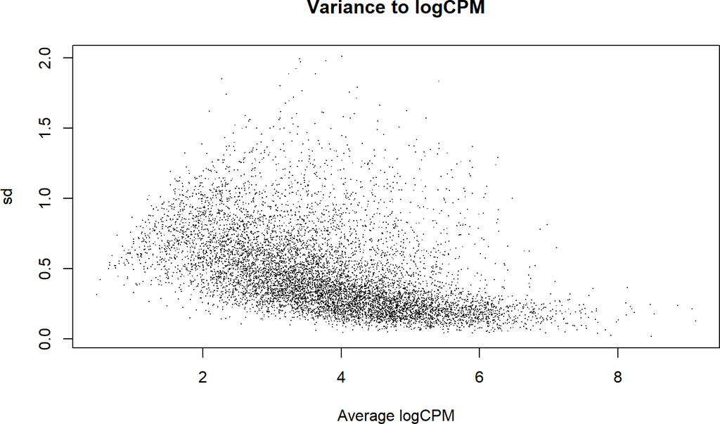

```r
cpm.mat <- log(cpm(assay(dds)))
mean.vec <- apply(cpm.mat, 1, mean)
sdvec <- apply(cpm.mat, 1, sd)
plot(mean.vec, sdvec, pch=".", main="Variance to logCPM", ylab="sd", xlab="Average logCPM")
```

##The mean-variance relationship (and what it means) In RNA-Seq data, genes with larger average expression have on average larger observed variances across samples, that is, they vary in expression from sample to sample more than other genes with lower average expression. This phenomena of ‘having different scatter’ is known as data heteroscedasticity. In our figures, we observe this heteroscedasticity except that the logarithmic transformation counteracts this and overdoes the adjustment somewhat so that large log-counts now have smaller scatter than small log-counts.

More, importantly we see the scatter tends to reduce as we increase the number of replicates. Standard deviations of averages are smaller than standard deviations of individual observations. So as you add more data (replicates), you get increasingly precise estimates of group means. With more precise estimates, we are more easily able to tell apart means which are close together.

## 8.2 Statistical models for DE analysis

edgeR and DESeq2 are two very popular tools which implement differential expression analysis on the basis of the NB model. They offer overlapping functionality but differ in the way dispersions are estimated. Accurate estimation of the dispersion parameter is critical for the statistical inference of differential expression. DESeq2

## 8.3 Transformations, Negative Bionomial Distribution,

This transformation normalizes the data according the presumed distribution of the count data

```r
rld <- rlog(dds_reduced, blind=FALSE)
rld
```

```
## class: DESeqTransform
## dim: 13308 8
## metadata(4): experimentData annotation protocolData version
## assays(1): ''
## rownames(13308): ENSMUSG00000000001 ENSMUSG00000000028 ...
##   ENSMUSG00000108791 ENSMUSG00000108806
## rowData names(33): ensembl_id gene_name ... maxCooks rlogIntercept
## colnames(8): HU_1-NS-012-053_S53_L001_R1_001.fastq.count
##   HU_1-NS-012-053_S53_L001_R2_001.fastq.count ...
##   HU_4-NS-012-056_S56_L001_R1_001.fastq.count
##   HU_4-NS-012-056_S56_L001_R2_001.fastq.count
## colData names(7): treatment sample_name ... condition sizeFactor
```

```r
head(assay(rld), 3)
```

```
##                    HU_1-NS-012-053_S53_L001_R1_001.fastq.count
## ENSMUSG00000000001                                    8.786036
## ENSMUSG00000000028                                    6.064985
## ENSMUSG00000000049                                    0.749819
##                    HU_1-NS-012-053_S53_L001_R2_001.fastq.count
## ENSMUSG00000000001                                   8.9111426
## ENSMUSG00000000028                                   6.1603155
## ENSMUSG00000000049                                   0.6990722
##                    HU_2-NS-012-054_S54_L001_R1_001.fastq.count
## ENSMUSG00000000001                                   8.9694440
## ENSMUSG00000000028                                   6.0824586
## ENSMUSG00000000049                                   0.7542909
##                    HU_2-NS-012-054_S54_L001_R2_001.fastq.count
## ENSMUSG00000000001                                    8.800201
## ENSMUSG00000000028                                    6.285628
## ENSMUSG00000000049                                    0.702426
##                    HU_3-NS-012-055_S55_L001_R1_001.fastq.count
## ENSMUSG00000000001                                   8.5695076
## ENSMUSG00000000028                                   6.0894976
## ENSMUSG00000000049                                   0.7996196
##                    HU_3-NS-012-055_S55_L001_R2_001.fastq.count
## ENSMUSG00000000001                                   8.4809414
## ENSMUSG00000000028                                   6.0782353
## ENSMUSG00000000049                                   0.7524547
##                    HU_4-NS-012-056_S56_L001_R1_001.fastq.count
## ENSMUSG00000000001                                   6.0433766
## ENSMUSG00000000028                                   6.2048274
## ENSMUSG00000000049                                   0.8085057
##                    HU_4-NS-012-056_S56_L001_R2_001.fastq.count
## ENSMUSG00000000001                                   6.1623220
## ENSMUSG00000000028                                   6.3053493
## ENSMUSG00000000049                                   0.6468089
```

## 8.4 PCA plot

The PCA plot can help detect interesting patterns in the data. It shows the raltive contribution to the variance in the data by groups. You can use the grouping variables to study clusters.

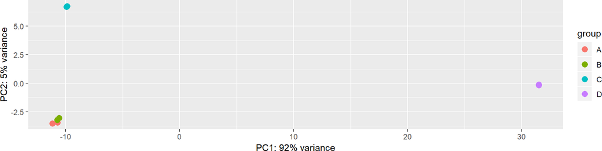

```r
plotPCA(rld, intgroup = c("condition"))
```

```r
colData(se) %>% as_tibble()
```

```
## # A tibble: 8 x 6
##   treatment   sample_name         cell_type exposure read_direction condition
##   <chr>       <chr>               <fct>     <fct>    <chr>          <fct>
## 1 JAWSIIuntr~ HU_1-NS-012-053_S5~ JAWSII    untreat~ forward        A
## 2 JAWSIIuntr~ HU_1-NS-012-053_S5~ JAWSII    untreat~ reverse        A
## 3 JAWSIILPSF  HU_2-NS-012-054_S5~ JAWSII    LPS      forward        B
## 4 JAWSIILPSR  HU_2-NS-012-054_S5~ JAWSII    LPS      reverse        B
## 5 EL4untreat~ HU_3-NS-012-055_S5~ EL4       untreat~ forward        C
## 6 EL4untreat~ HU_3-NS-012-055_S5~ EL4       untreat~ reverse        C
## 7 EL4JAWSIIL~ HU_4-NS-012-056_S5~ EL4-JAWS~ SUP      forward        D
## 8 EL4JAWSIIL~ HU_4-NS-012-056_S5~ EL4-JAWS~ SUP      reverse        D
```

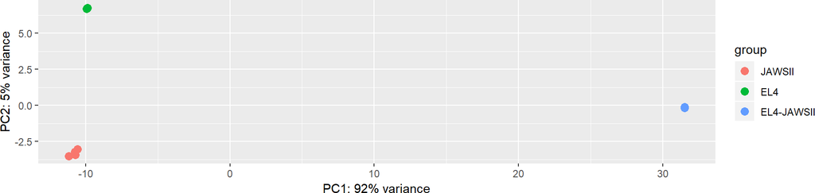

```r
plotPCA(rld, intgroup = c("cell_type"))
```

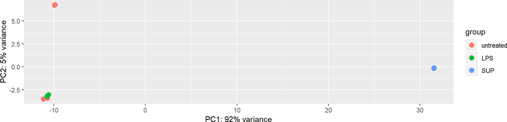

```r
plotPCA(rld, intgroup = c("exposure"))
```

## 8.5 Summarizing statistics

```r
dds <- DESeq(dds_reduced)
res <- results(dds)

summary(res)
```

```
##
## out of 13308 with nonzero total read count
## adjusted p-value < 0.1
## LFC > 0 (up)       : 1865, 14%
## LFC < 0 (down)     : 2385, 18%
## outliers [1]       : 0, 0%
## low counts [2]     : 2580, 19%
## (mean count < 1)
## [1] see 'cooksCutoff' argument of ?results
## [2] see 'independentFiltering' argument of ?results
```

```r
resLFC1 <- results(dds, lfcThreshold=1)
table(resLFC1$padj < 0.1)
```

```
##
## FALSE  TRUE
##  8836   860
```

```r
sum(res$padj < 0.1, na.rm=TRUE)
```

```
## [1] 4250
```

# 9 Plotting dispersion estimates

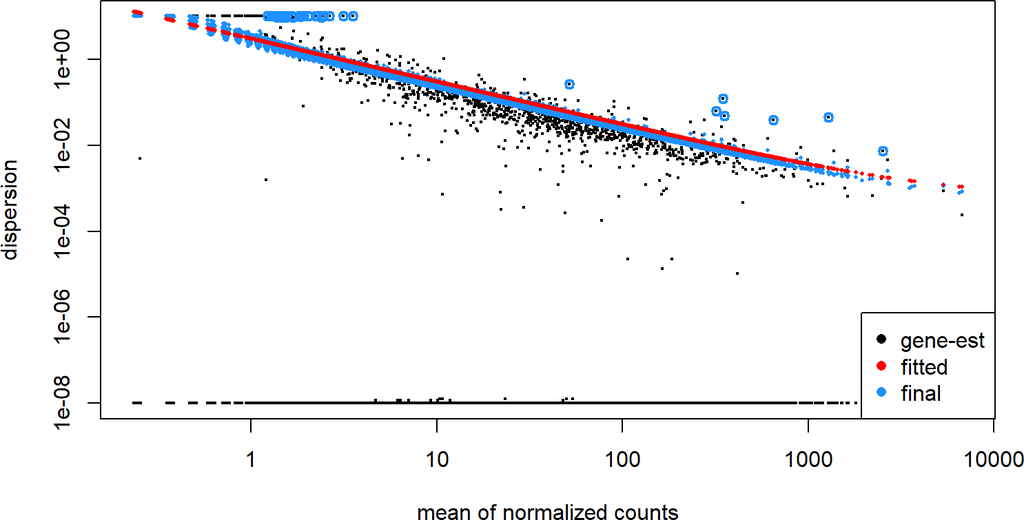

```r
plotDispEsts(dds)
```

## 9.1 Gene and protein name for TopGene

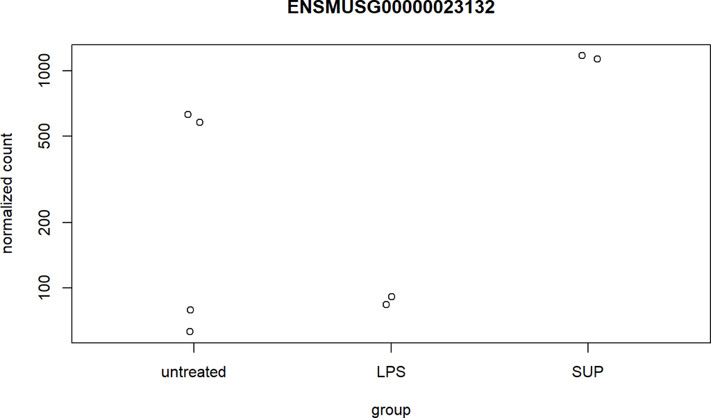

```r
topGene <- rownames(res)[which.min(res$padj)]
plotCounts(dds, gene=topGene, intgroup=c("exposure"))
```

```r
topGene
```

```
## [1] "ENSMUSG00000023132"
```

## 9.2 looking up the top gene from ENSML BioMart

```r
library(biomaRt)
ensembl = useEnsembl(biomart="ensembl", dataset="mmusculus_gene_ensembl")
topProtein <- getBM(attributes=c('ensembl_gene_id','ensembl_transcript_id','hgnc_symbol','hgnc_id', 'external_gene_name'),filters = 'ensembl_gene_id', values = topGene, mart = ensembl)
topProtein
```

```
##      ensembl_gene_id ensembl_transcript_id hgnc_symbol hgnc_id
## 1 ENSMUSG00000023132    ENSMUST00000224282          NA      NA
## 2 ENSMUSG00000023132    ENSMUST00000023897          NA      NA
##   external_gene_name
## 1               Gzma
## 2               Gzma
```

## 9.3 A nicer graph with ggplot2

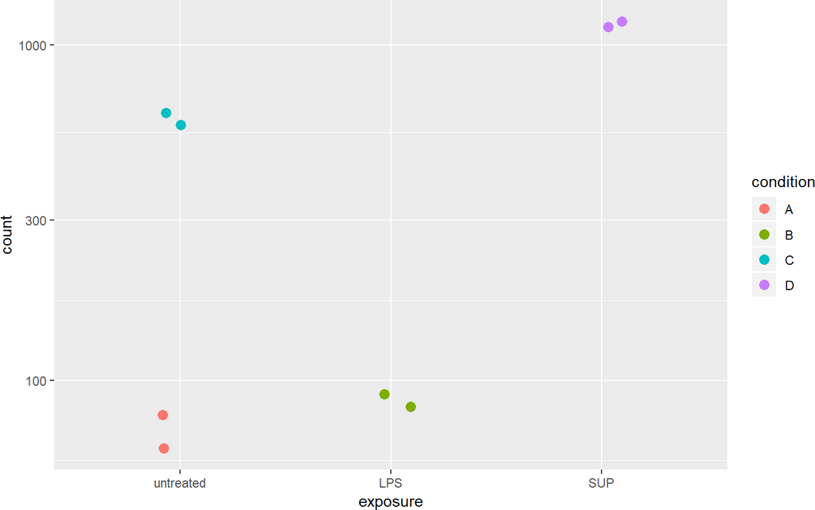

```r
geneCounts <- plotCounts(dds, gene=topGene, intgroup=c("condition", "exposure"), returnData=TRUE)
ggplot(geneCounts, aes(x=exposure, y=count, color=condition)) +
  scale_y_log10() +
  geom_point(position=position_jitter(width=.1,height=0), size=3)
```

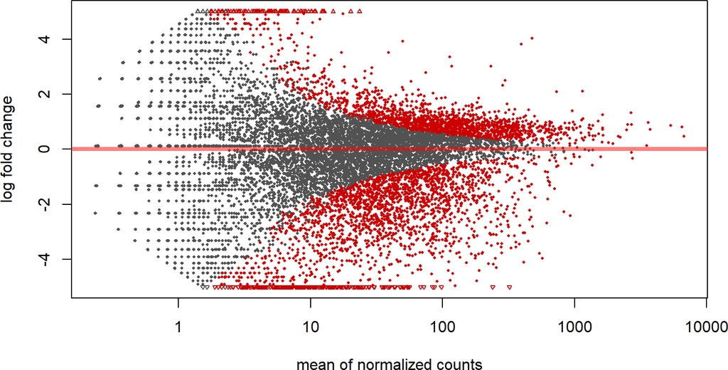

```r
plotMA(res, ylim=c(-5,5))
```

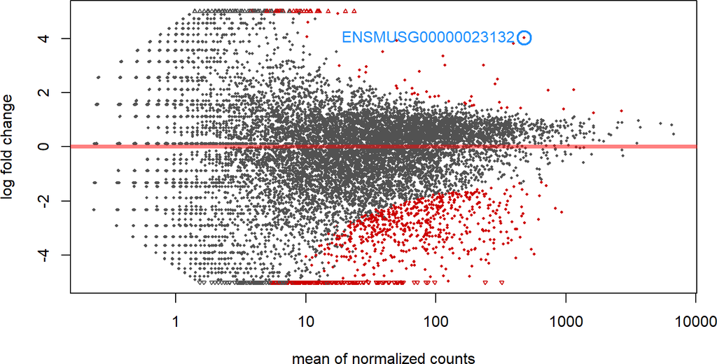

```r
plotMA(resLFC1, ylim=c(-5,5))
topGene <- rownames(resLFC1)[which.min(resLFC1$padj)]
with(resLFC1[topGene, ], {
  points(baseMean, log2FoldChange, col="dodgerblue", cex=2, lwd=2)
  text(baseMean, log2FoldChange, topGene, pos=2, col="dodgerblue")
})
```

## 9.5 Heatmap of top 10 transcripts

```r
library(genefilter)
topVarGenes <- head(order(rowVars(assay(rld)),
                          decreasing=TRUE), 10)

mat_10 <- assay(rld)[ topVarGenes, ]
mat_10
```

```
##                    HU_1-NS-012-053_S53_L001_R1_001.fastq.count
## ENSMUSG00000002718                                    8.681856
## ENSMUSG00000023132                                    6.478352
## ENSMUSG00000075602                                    6.213335
## ENSMUSG00000025240                                    8.696347
## ENSMUSG00000030978                                    8.960386
## ENSMUSG00000026355                                    9.645012
## ENSMUSG00000021595                                    9.535537
## ENSMUSG00000050912                                    7.753154
## ENSMUSG00000022043                                    8.578432
## ENSMUSG00000026553                                    8.376192
##                    HU_1-NS-012-053_S53_L001_R2_001.fastq.count
## ENSMUSG00000002718                                    8.701183
## ENSMUSG00000023132                                    6.207301
## ENSMUSG00000075602                                    6.413346
## ENSMUSG00000025240                                    8.582791
## ENSMUSG00000030978                                    9.101261
## ENSMUSG00000026355                                    9.546460
## ENSMUSG00000021595                                    9.522516
## ENSMUSG00000050912                                    7.809465
## ENSMUSG00000022043                                    8.296775
## ENSMUSG00000026553                                    8.202032
##                    HU_2-NS-012-054_S54_L001_R1_001.fastq.count
## ENSMUSG00000002718                                    8.692196
## ENSMUSG00000023132                                    6.551243
## ENSMUSG00000075602                                    6.201393
## ENSMUSG00000025240                                    8.086255
## ENSMUSG00000030978                                    9.082845
## ENSMUSG00000026355                                    9.473970
## ENSMUSG00000021595                                    9.392457
## ENSMUSG00000050912                                    7.507431
## ENSMUSG00000022043                                    8.219338
## ENSMUSG00000026553                                    8.323914
##                    HU_2-NS-012-054_S54_L001_R2_001.fastq.count
## ENSMUSG00000002718                                    8.758111
## ENSMUSG00000023132                                    6.654106
## ENSMUSG00000075602                                    6.203361
## ENSMUSG00000025240                                    8.088738
## ENSMUSG00000030978                                    9.146422
## ENSMUSG00000026355                                    9.463789
```

[output cut: 33 more lines]

```
## ENSMUSG00000021595                                    6.243468
## ENSMUSG00000050912                                    4.425421
## ENSMUSG00000022043                                    5.136092
## ENSMUSG00000026553                                    5.358821
##                    HU_4-NS-012-056_S56_L001_R2_001.fastq.count
## ENSMUSG00000002718                                    4.744206
## ENSMUSG00000023132                                   10.097956
## ENSMUSG00000075602                                    9.817247
## ENSMUSG00000025240                                    4.697432
## ENSMUSG00000030978                                    5.516328
## ENSMUSG00000026355                                    6.071530
## ENSMUSG00000021595                                    6.028496
## ENSMUSG00000050912                                    4.699246
## ENSMUSG00000022043                                    5.039677
## ENSMUSG00000026553                                    5.208682
```

```r
mat_10 <- mat_10 - rowMeans(mat_10)
df <- as.data.frame(colData(rld)[,c("condition")])

png(filename = paste0(root, "/images/10genes.png"), res = 600, width = 14, height = 20, units = "cm")
pheatmap(mat_10, show_rownames = TRUE)
dev.off()
```

```r
## ?pheatmap
row.names(mat_10)
```

```
##  [1] "ENSMUSG00000002718" "ENSMUSG00000023132" "ENSMUSG00000075602"
##  [4] "ENSMUSG00000025240" "ENSMUSG00000030978" "ENSMUSG00000026355"
##  [7] "ENSMUSG00000021595" "ENSMUSG00000050912" "ENSMUSG00000022043"
## [10] "ENSMUSG00000026553"
```

## 9.6 heatmap of top 1000 transcripts

```r
topVarGenes <- head(order(rowVars(assay(rld)), decreasing=TRUE), 1000)

mat_1000 <- assay(rld)[ topVarGenes, ]

mat_1000 <- mat_1000 - rowMeans(mat_1000) ## normalize by row
## df <- as.data.frame(colData(rld)[,c("treatment")])
png(filename = paste0(root, "/images/1000genes.png"), res = 600, width = 8, height = 10, units = "cm")
pheatmap(mat_1000, show_rownames = FALSE)
dev.off()
```

```r
?pheatmap

row.names(mat_1000)
```

```
##    [1] "ENSMUSG00000002718" "ENSMUSG00000023132" "ENSMUSG00000075602"
##    [4] "ENSMUSG00000025240" "ENSMUSG00000030978" "ENSMUSG00000026355"
##    [7] "ENSMUSG00000021595" "ENSMUSG00000050912" "ENSMUSG00000022043"
##   [10] "ENSMUSG00000026553" "ENSMUSG00000031696" "ENSMUSG00000032116"
##   [13] "ENSMUSG00000017707" "ENSMUSG00000023150" "ENSMUSG00000032058"
##   [16] "ENSMUSG00000021072" "ENSMUSG00000031826" "ENSMUSG00000014956"
##   [19] "ENSMUSG00000004880" "ENSMUSG00000016018" "ENSMUSG00000026229"
##   [22] "ENSMUSG00000021754" "ENSMUSG00000024231" "ENSMUSG00000027429"
##   [25] "ENSMUSG00000029686" "ENSMUSG00000031557" "ENSMUSG00000000751"
##   [28] "ENSMUSG00000032902" "ENSMUSG00000025968" "ENSMUSG00000070372"
##   [31] "ENSMUSG00000037458" "ENSMUSG00000024370" "ENSMUSG00000025903"
##   [34] "ENSMUSG00000020719" "ENSMUSG00000031207" "ENSMUSG00000040084"
##   [37] "ENSMUSG00000029767" "ENSMUSG00000032939" "ENSMUSG00000029176"
##   [40] "ENSMUSG00000038212" "ENSMUSG00000000001" "ENSMUSG00000032096"
##   [43] "ENSMUSG00000020464" "ENSMUSG00000041859" "ENSMUSG00000020917"
```

[output cut: 319 more lines]

## 9.7 heatmap of top 10000 transcripts

```r
topVarGenes <- head(order(rowVars(assay(rld)), decreasing=TRUE), 10000)

mat_10000 <- assay(rld)[ topVarGenes, ]

mat_10000 <- mat_10000 - rowMeans(mat_10000)
## df <- as.data.frame(colData(rld)[,c("treatment")])
png(filename = paste0(root, "/images/10000genes.png"), res = 600, width = 8, height = 30, units = "cm")
pheatmap(mat_10000, show_rownames = FALSE)
dev.off()
```

```r
?pheatmap

row.names(mat_10000)
```

```
##     [1] "ENSMUSG00000002718" "ENSMUSG00000023132" "ENSMUSG00000075602"
##     [4] "ENSMUSG00000025240" "ENSMUSG00000030978" "ENSMUSG00000026355"
##     [7] "ENSMUSG00000021595" "ENSMUSG00000050912" "ENSMUSG00000022043"
##    [10] "ENSMUSG00000026553" "ENSMUSG00000031696" "ENSMUSG00000032116"
##    [13] "ENSMUSG00000017707" "ENSMUSG00000023150" "ENSMUSG00000032058"
##    [16] "ENSMUSG00000021072" "ENSMUSG00000031826" "ENSMUSG00000014956"
##    [19] "ENSMUSG00000004880" "ENSMUSG00000016018" "ENSMUSG00000026229"
##    [22] "ENSMUSG00000021754" "ENSMUSG00000024231" "ENSMUSG00000027429"
##    [25] "ENSMUSG00000029686" "ENSMUSG00000031557" "ENSMUSG00000000751"
##    [28] "ENSMUSG00000032902" "ENSMUSG00000025968" "ENSMUSG00000070372"
##    [31] "ENSMUSG00000037458" "ENSMUSG00000024370" "ENSMUSG00000025903"
##    [34] "ENSMUSG00000020719" "ENSMUSG00000031207" "ENSMUSG00000040084"
##    [37] "ENSMUSG00000029767" "ENSMUSG00000032939" "ENSMUSG00000029176"
##    [40] "ENSMUSG00000038212" "ENSMUSG00000000001" "ENSMUSG00000032096"
##    [43] "ENSMUSG00000020464" "ENSMUSG00000041859" "ENSMUSG00000020917"
```

[output cut: 3319 more lines]

## 9.8 Get gene names and protein from ENSMBL IDs

```r
library(biomaRt)

mart = useMart("ensembl", dataset = "mmusculus_gene_ensembl")
listDatasets(mart)
```

```
##                            dataset
## 1     abrachyrhynchus_gene_ensembl
## 2         acalliptera_gene_ensembl
## 3       acarolinensis_gene_ensembl
## 4        acitrinellus_gene_ensembl
## 5            ahaastii_gene_ensembl
## 6        amelanoleuca_gene_ensembl
## 7          amexicanus_gene_ensembl
## 8          anancymaae_gene_ensembl
## 9          aocellaris_gene_ensembl
## 10            aowenii_gene_ensembl
## 11           apercula_gene_ensembl
## 12     aplatyrhynchos_gene_ensembl
## 13      apolyacanthus_gene_ensembl
## 14              arowi_gene_ensembl
```

[output cut: 540 more lines]

```r
attributes <- as_tibble(listAttributes(mart))

# help on biomaRt
?useMart
?listMarts()
listMarts()
```

```
##                biomart               version
## 1 ENSEMBL_MART_ENSEMBL      Ensembl Genes 96
## 2   ENSEMBL_MART_MOUSE      Mouse strains 96
## 3     ENSEMBL_MART_SNP  Ensembl Variation 96
## 4 ENSEMBL_MART_FUNCGEN Ensembl Regulation 96
```

```r
## for the 10 genes
ensembl = useEnsembl(biomart="ensembl", dataset="mmusculus_gene_ensembl")

getBM(attributes = c('entrezgene','hgnc_symbol'),
      filters = 'go',
      values = 'GO:0004707',
      mart = mart)
```

```
##    entrezgene hgnc_symbol
## 1       26419          NA
## 2       26414          NA
## 3       18099          NA
## 4       23939          NA
## 5       50772          NA
## 6       26416          NA
## 7       26415          NA
## 8       29857          NA
## 9       19094          NA
## 10     225724          NA
## 11      26420          NA
## 12      26413          NA
## 13     332110          NA
## 14      26417          NA
```

```r
## for the 10000 genes
ensembl = useEnsembl(biomart="ensembl", dataset="mmusculus_gene_ensembl")

topVarGenes <- head(order(rowVars(assay(rld)), decreasing=TRUE), 10000)

mat_10000 <- assay(rld)[ topVarGenes, ]

mat_10000 <- mat_10000 - rowMeans(mat_10000)
head(mat_10000)
```

```
##                    HU_1-NS-012-053_S53_L001_R1_001.fastq.count
## ENSMUSG00000002718                                   1.0225251
## ENSMUSG00000023132                                  -1.5696145
## ENSMUSG00000075602                                  -1.5710589
## ENSMUSG00000025240                                   1.3851858
## ENSMUSG00000030978                                   0.8099232
## ENSMUSG00000026355                                   1.0045586
##                    HU_1-NS-012-053_S53_L001_R2_001.fastq.count
## ENSMUSG00000002718                                   1.0418517
## ENSMUSG00000023132                                  -1.8406661
## ENSMUSG00000075602                                  -1.3710481
## ENSMUSG00000025240                                   1.2716299
## ENSMUSG00000030978                                   0.9507988
## ENSMUSG00000026355                                   0.9060067
##                    HU_2-NS-012-054_S54_L001_R1_001.fastq.count
## ENSMUSG00000002718                                   1.0328647
## ENSMUSG00000023132                                  -1.4967236
## ENSMUSG00000075602                                  -1.5830012
## ENSMUSG00000025240                                   0.7750941
## ENSMUSG00000030978                                   0.9323821
## ENSMUSG00000026355                                   0.8335170
##                    HU_2-NS-012-054_S54_L001_R2_001.fastq.count
## ENSMUSG00000002718                                   1.0987800
## ENSMUSG00000023132                                  -1.3938604
## ENSMUSG00000075602                                  -1.5810327
## ENSMUSG00000025240                                   0.7775772
## ENSMUSG00000030978                                   0.9959596
## ENSMUSG00000026355                                   0.8233360
##                    HU_3-NS-012-055_S55_L001_R1_001.fastq.count
## ENSMUSG00000002718                                   0.8202329
## ENSMUSG00000023132                                   1.0690656
## ENSMUSG00000075602                                   1.0623298
## ENSMUSG00000025240                                   0.4655182
## ENSMUSG00000030978                                   0.6787272
## ENSMUSG00000026355                                   0.8362301
##                    HU_3-NS-012-055_S55_L001_R2_001.fastq.count
## ENSMUSG00000002718                                   0.9268368
## ENSMUSG00000023132                                   1.1828640
## ENSMUSG00000075602                                   0.9895062
## ENSMUSG00000025240                                   0.3868705
## ENSMUSG00000030978                                   0.8062037
## ENSMUSG00000026355                                   0.7336016
##                    HU_4-NS-012-056_S56_L001_R1_001.fastq.count
## ENSMUSG00000002718                                   -3.027966
## ENSMUSG00000023132                                    1.998946
## ENSMUSG00000075602                                    2.021452
## ENSMUSG00000025240                                   -2.448146
## ENSMUSG00000030978                                   -2.539860
## ENSMUSG00000026355                                   -2.568327
##                    HU_4-NS-012-056_S56_L001_R2_001.fastq.count
## ENSMUSG00000002718                                   -2.915125
## ENSMUSG00000023132                                    2.049989
## ENSMUSG00000075602                                    2.032853
## ENSMUSG00000025240                                   -2.613729
## ENSMUSG00000030978                                   -2.634134
## ENSMUSG00000026355                                   -2.568923
```

```r
annotations_10000 <-
           getBM(attributes=c('go_id',
                              'ensembl_gene_id',                                              'ensembl_transcript_id',
                              'hgnc_symbol',
                              'hgnc_id',
                              'external_gene_name',
                              'ensembl_peptide_id',
                              'description'),
                 filters = 'ensembl_gene_id',
                 values = row.names(mat_10000),
                 mart = ensembl)

head(annotations_10000)
```

```
##        go_id    ensembl_gene_id ensembl_transcript_id hgnc_symbol hgnc_id
## 1            ENSMUSG00000027763    ENSMUST00000195724          NA      NA
## 2 GO:0046872 ENSMUSG00000027763    ENSMUST00000195077          NA      NA
## 3            ENSMUSG00000027763    ENSMUST00000195832          NA      NA
## 4 GO:0046872 ENSMUSG00000027763    ENSMUST00000193647          NA      NA
## 5            ENSMUSG00000027763    ENSMUST00000195001          NA      NA
## 6 GO:0046872 ENSMUSG00000027763    ENSMUST00000192807          NA      NA
##   external_gene_name ensembl_peptide_id
## 1              Mbnl1 ENSMUSP00000141984
## 2              Mbnl1 ENSMUSP00000142074
## 3              Mbnl1
## 4              Mbnl1 ENSMUSP00000141536
## 5              Mbnl1 ENSMUSP00000141848
## 6              Mbnl1 ENSMUSP00000141915
##                                                              description
## 1 muscleblind like splicing factor 1 [Source:MGI Symbol;Acc:MGI:1928482]
## 2 muscleblind like splicing factor 1 [Source:MGI Symbol;Acc:MGI:1928482]
## 3 muscleblind like splicing factor 1 [Source:MGI Symbol;Acc:MGI:1928482]
## 4 muscleblind like splicing factor 1 [Source:MGI Symbol;Acc:MGI:1928482]
## 5 muscleblind like splicing factor 1 [Source:MGI Symbol;Acc:MGI:1928482]
## 6 muscleblind like splicing factor 1 [Source:MGI Symbol;Acc:MGI:1928482]
```

```r
annotations_10000_df <- as_tibble(annotations_10000)
```

## 9.9 A function to create a heatmap based on the number of top genes and annotians on the basis of go terms

```r
rld = rld
number_top_genes = 1000
go_term = "GO:0005576"

create_annotated_heatmap <- function(rld,
                                     number_top_genes,
                                     go_term){

  topVarGenes <- head(order(rowVars(assay(rld)),
                              decreasing=TRUE),
                              number_top_genes)

counts_matrix <- assay(rld)[ topVarGenes, ]

annotations <-
      getBM(attributes=c(
                'go_id',
                'ensembl_gene_id',                                                             'ensembl_transcript_id',
                'hgnc_symbol',
                'hgnc_id',
                'external_gene_name',
                'ensembl_peptide_id',
                'description'),
                 filters = 'ensembl_gene_id',
                 values = row.names(counts_matrix),
                 mart = ensembl)

# convert to dataframe
df <- as_tibble(counts_matrix)
df$gene_id <- row.names(counts_matrix)

atribute_filtered <- annotations %>%
  filter(go_id == go_term)


library(dplyr)
filtered_df <- mat_1000_df %>%
      filter(gene_id %in% GO_0005576_extracellular$ensembl_gene_id)

head(GO_df)














mat_1000 <- mat_1000 - rowMeans(mat_1000)
## df <- as.data.frame(colData(rld)[,c("treatment")])
png(filename = paste0(root, "/images/1000genes.png"), res = 600, width = 8, height = 10, units = "cm")
pheatmap(mat_1000, show_rownames = FALSE)
dev.off()




}
```